# Species metadata description

# Biodiversity mapping

The following pdf gives a description of the data used in the pipeline run that corresponds to the folder this document resides in. It should be used as a guide for anyone who wants to know more about the data used in the corresponding outputs (maps and datasets) and/or would like to replicate the data.

We begin with basic information about the pipeline run.

| Characteristic | Value |
| --- | --- |
| Date | 2025-01-02 |
| Taxa | spiders, beetles, cockroaches, snakeflies, scorpionflies, bugs, netWingedInsects, grasshopperLikeInsects, earwigs, butterfliesMoths, flies, hymenopterans, aquaticInsects |
| Region type | country |
| Region code | Norway |
| Total species | 19353 |
| Total datasets used | 36 |
| DOI | 10.15468/dl.xccvjz |

In addition to the above, data was downloaded with a maximum uncertainty regarding coordinates of 100 metres.

The following shows total number of species per taxa and per dataset from the initial download from GBIF and ANO. Note that only the top 10 datasets are shown. A full list of observations per dataset per taxa as well as observations per species can be found in the appendices.

| taxa | species | redListedSpecies |
| --- | --- | --- |
| aquaticInsects | 453 | 5 |
| beetles | 3856 | 9 |
| bugs | 1021 | 1 |
| butterfliesMoths | 2630 | 47 |
| cockroaches | 10 | 0 |
| earwigs | 9 | 0 |
| flies | 5672 | 9 |
| grasshopperLikeInsects | 42 | 2 |
| hymenopterans | 4175 | 11 |
| netWingedInsects | 70 | 1 |
| scorpionflies | 10 | 0 |
| snakeflies | 7 | 0 |
| spiders | 1398 | 3 |

| dsName | dataType | observations | redListedObservations |
| --- | --- | --- | --- |
| Freshwater benthic invertebrates ecological collection NTNU University Museum | PA | 18336711 | 0 |
| Bumblebees and butterflies in Norway | PA | 3501594 | 123579 |
| Norwegian Species Observation Service | PO | 1429518 | 9554 |
| National insect monitoring in Norway | Counts | 1057323 | 1570 |
| Entomology, Oslo (O) UiO | PO | 268872 | 1730 |
| Effects of vegetation clearing and dead wood on beetles in power line clearings southeast Norway | PA | 225292 | 180 |
| Terrestrial and limnic invertebrates systematic collection, NTNU University Museum | PO | 192377 | 304 |
| NINA insect database | PO | 139495 | 12180 |
| Beetles in previous clear-cut and near natural mature spruce forests in southern Norway | PA | 109310 | 0 |
| Solitary bees collected in a large-scale field experiment in power line clearings, southeast Norway | PA | 92518 | 0 |

The following gives species richness for observations across the surveyed region by taxa.

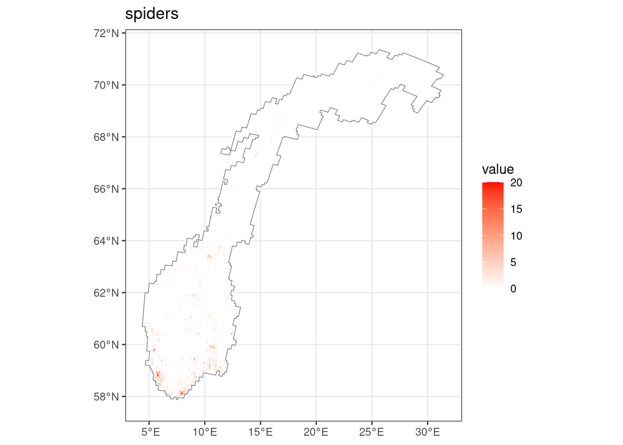

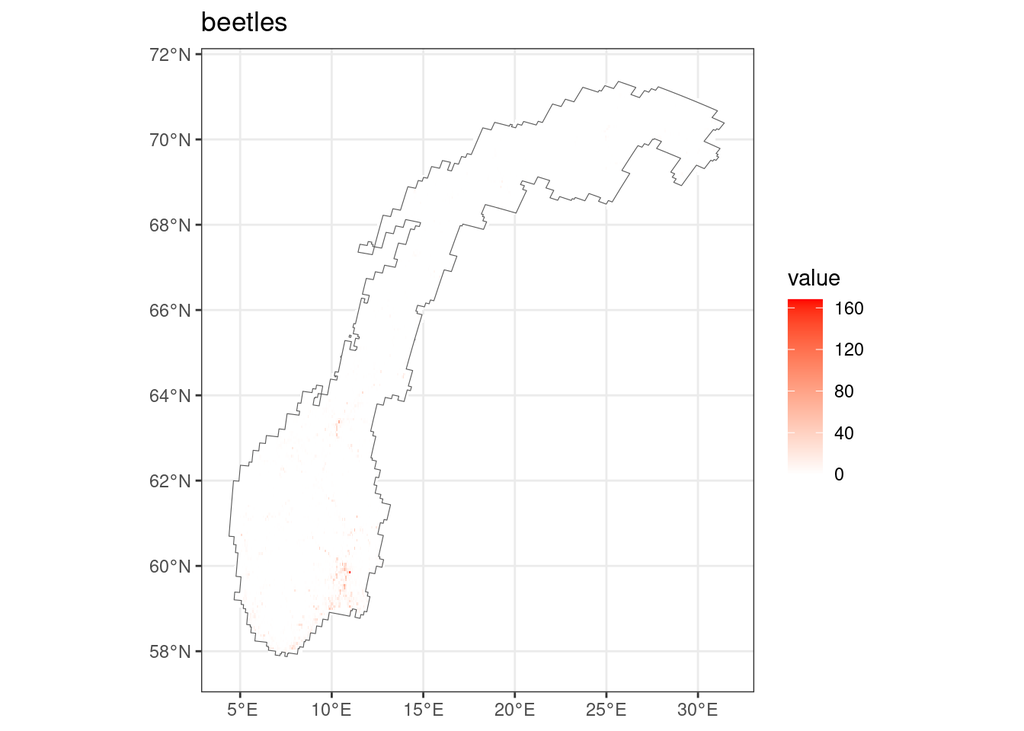

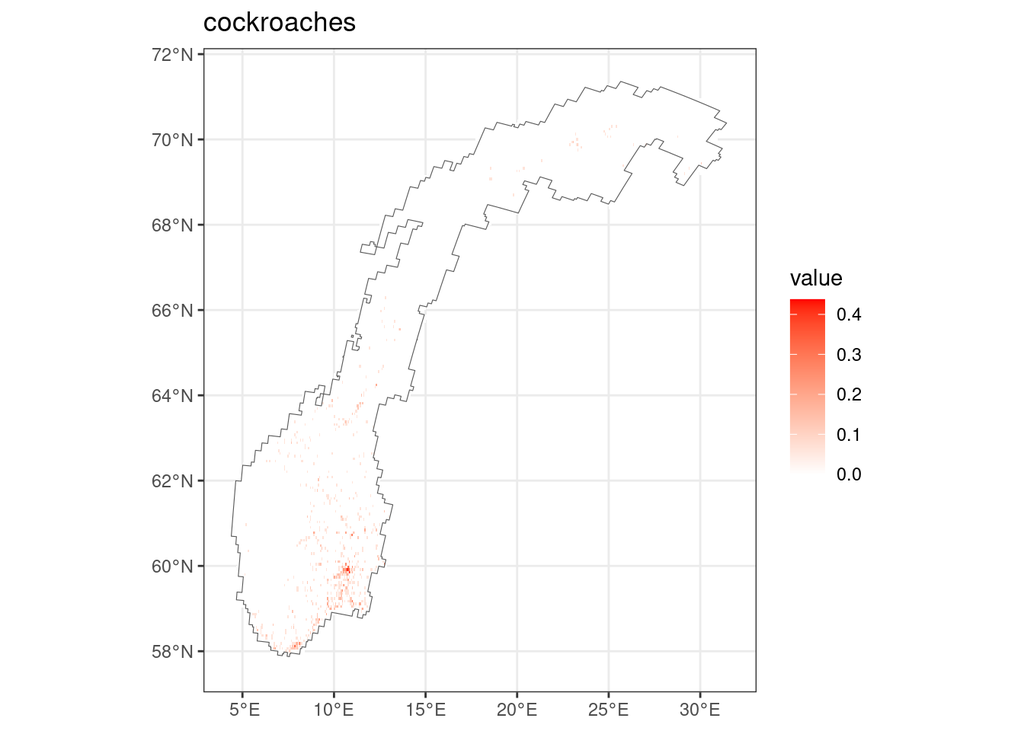

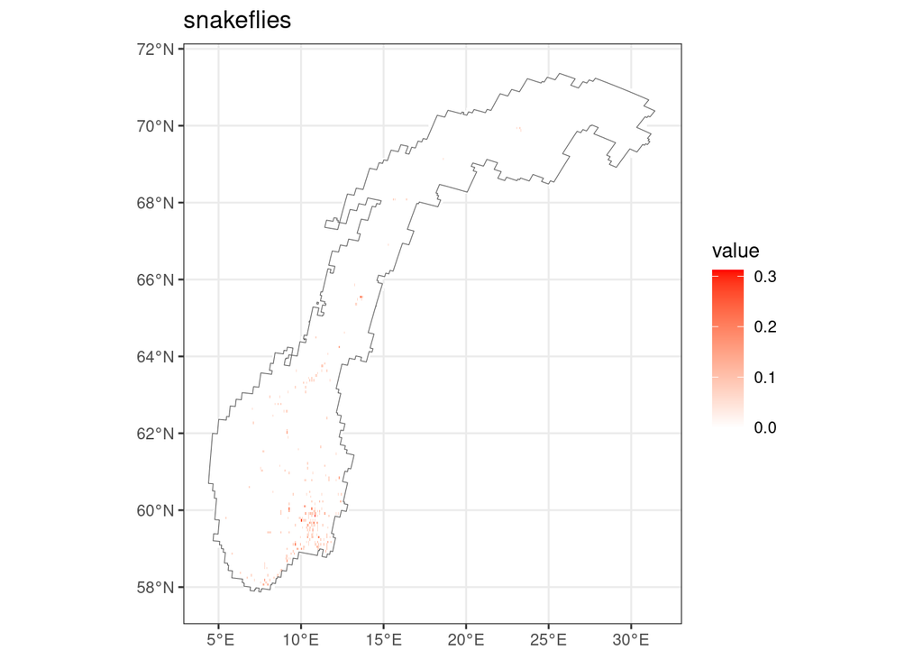

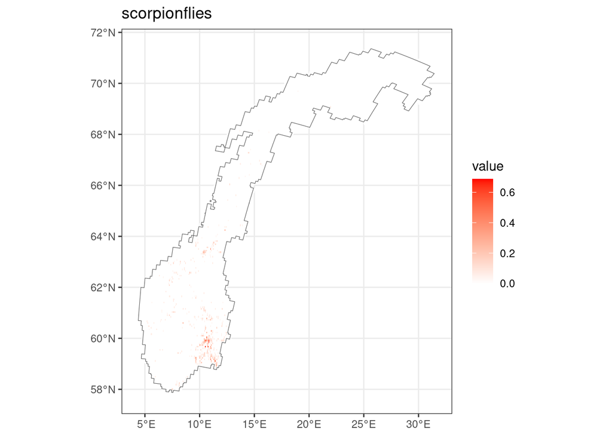

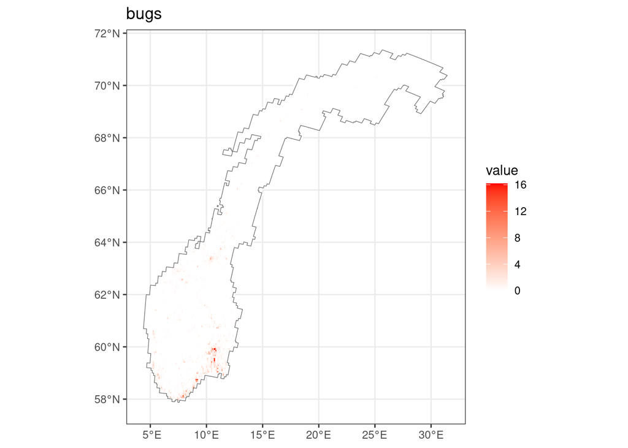

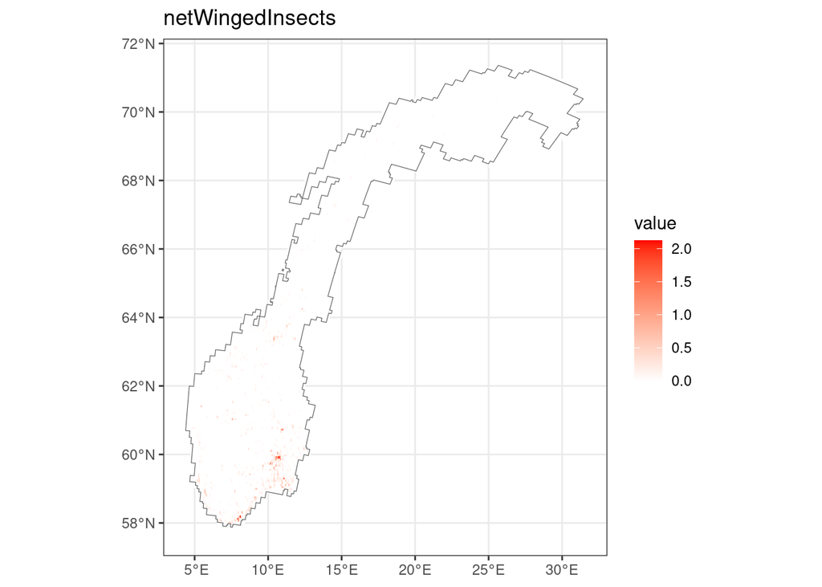

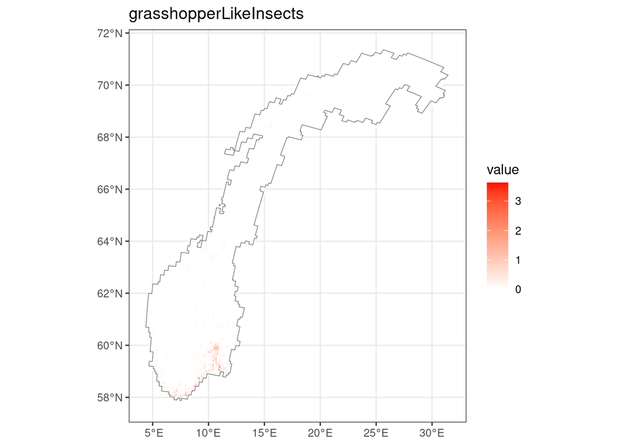

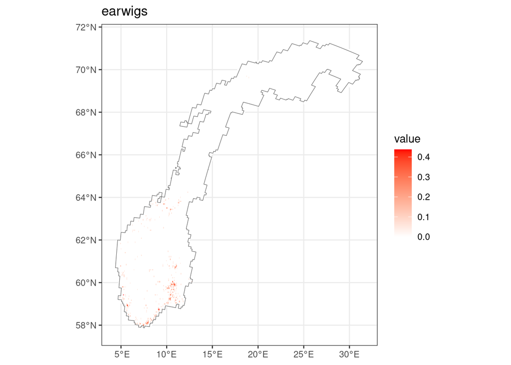

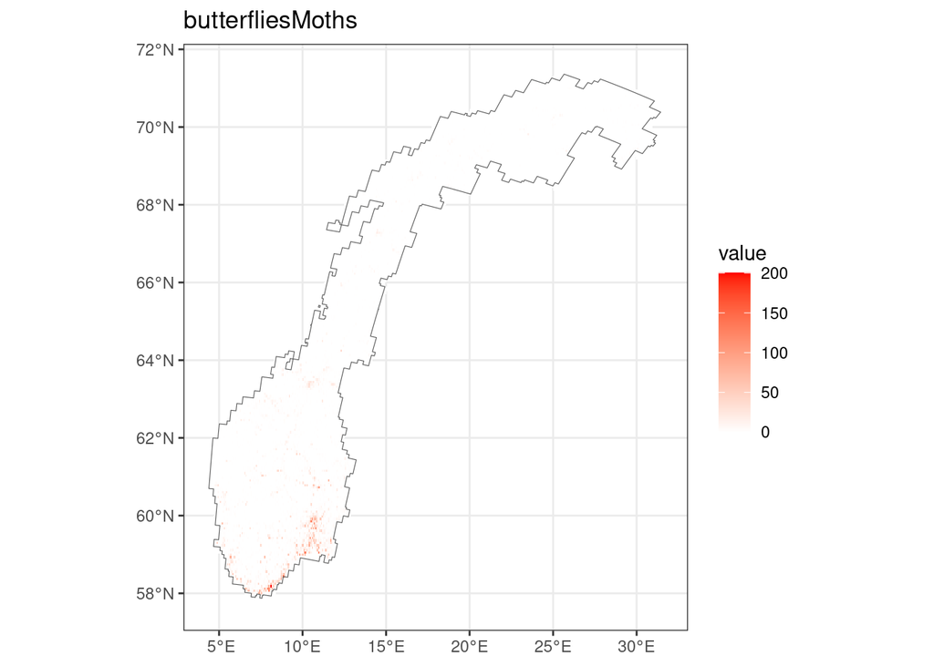

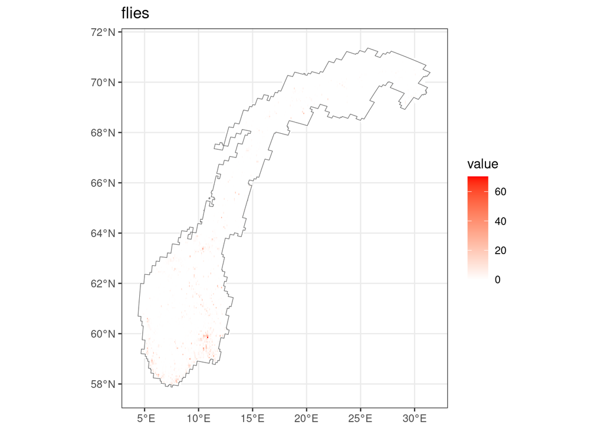

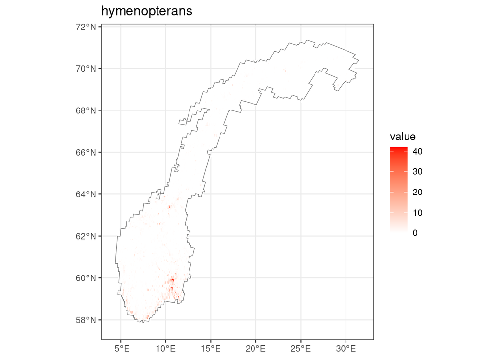

[1 more figures not shown]

The following gives spatial density for observations across the surveyed region by taxa.

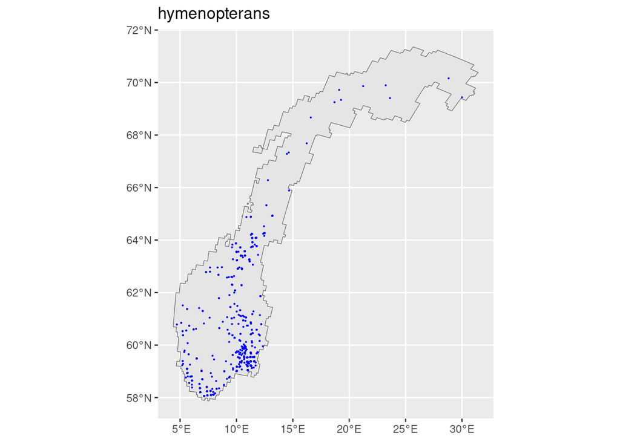

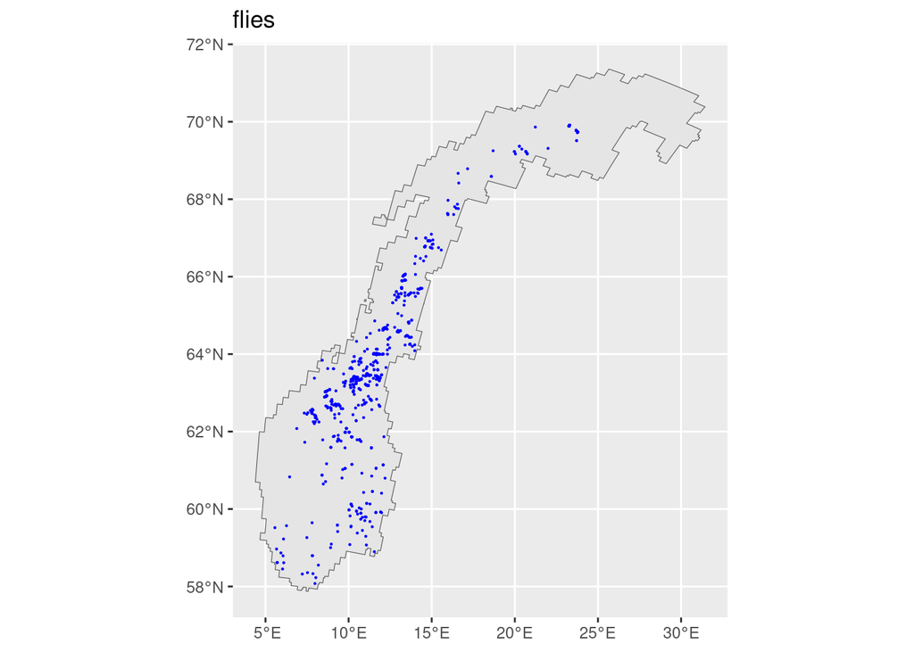

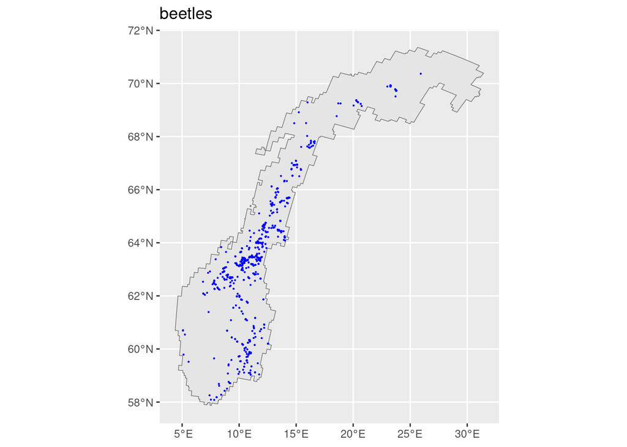

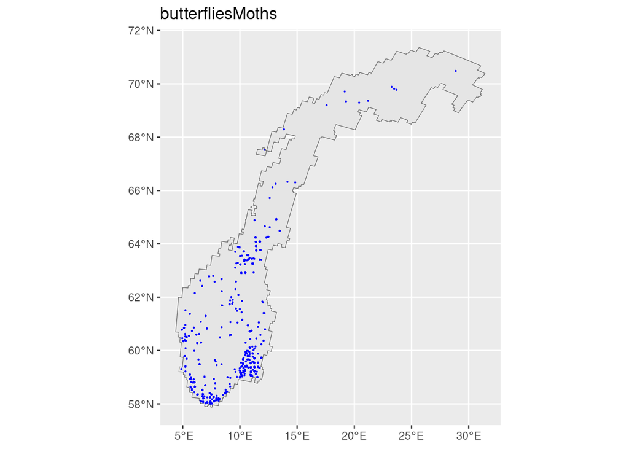

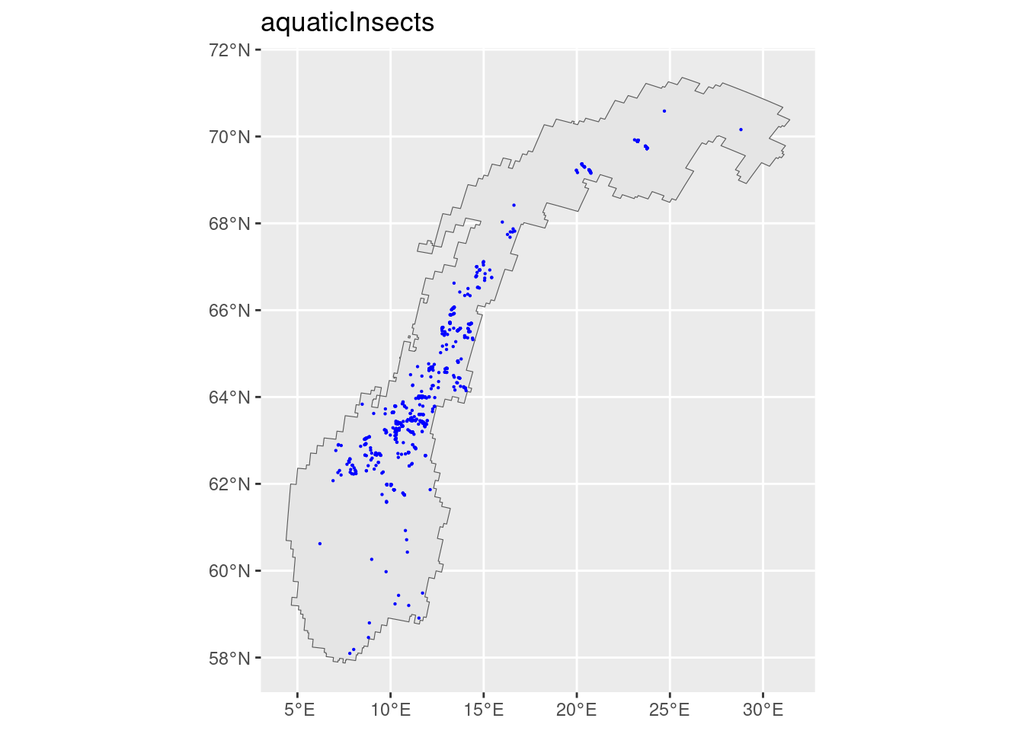

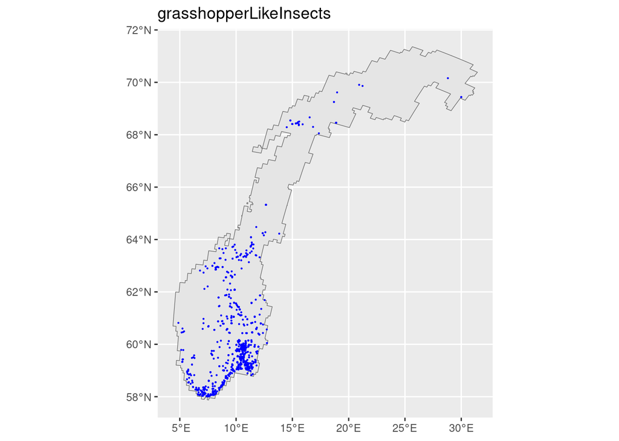

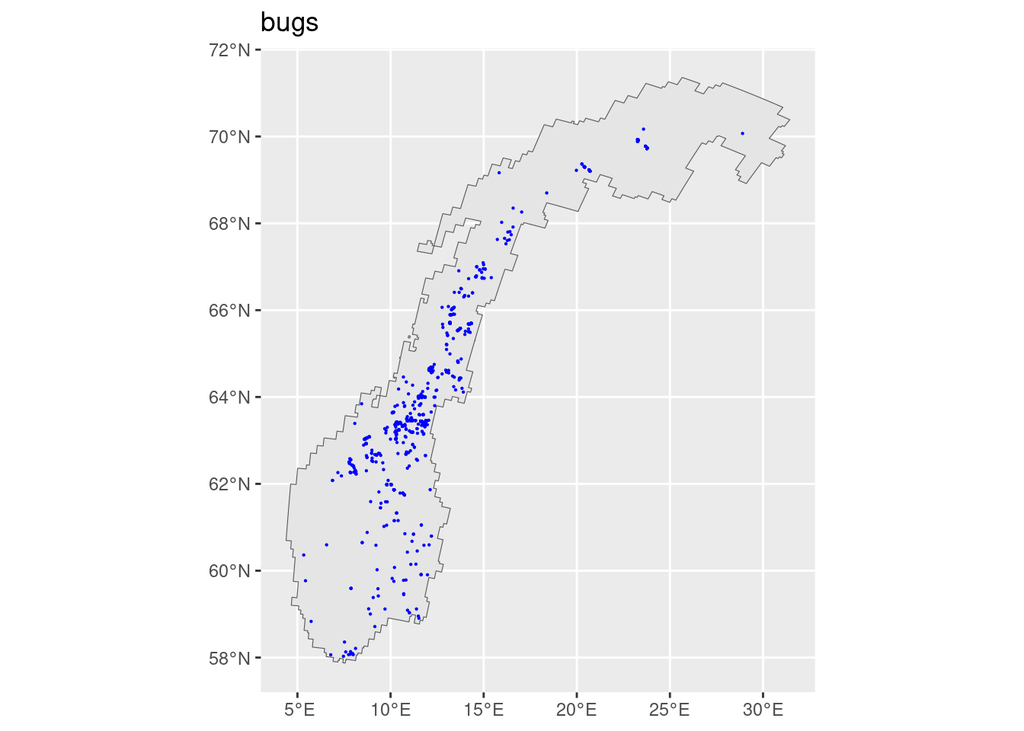

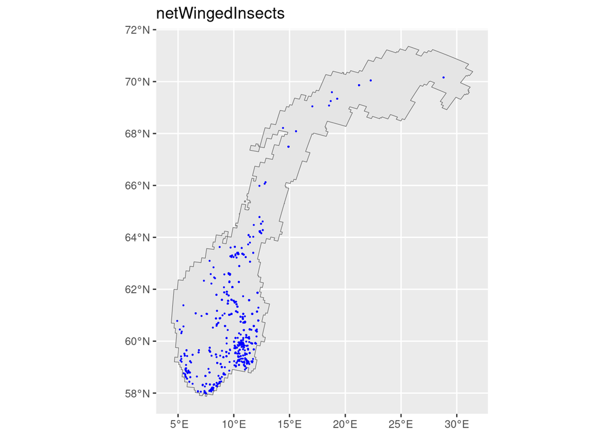

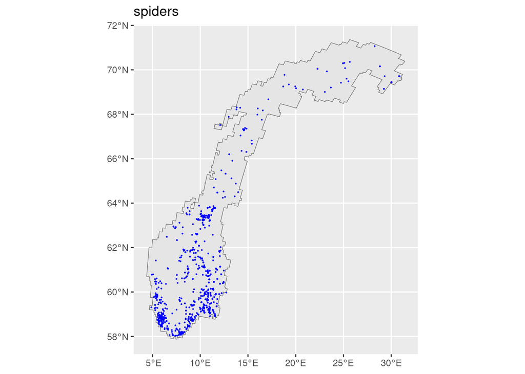

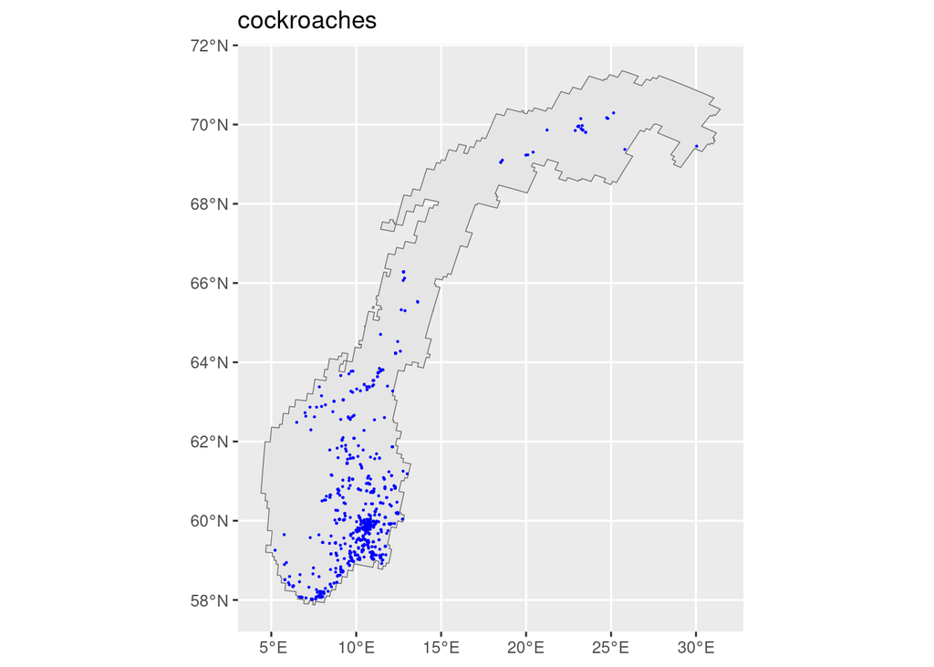

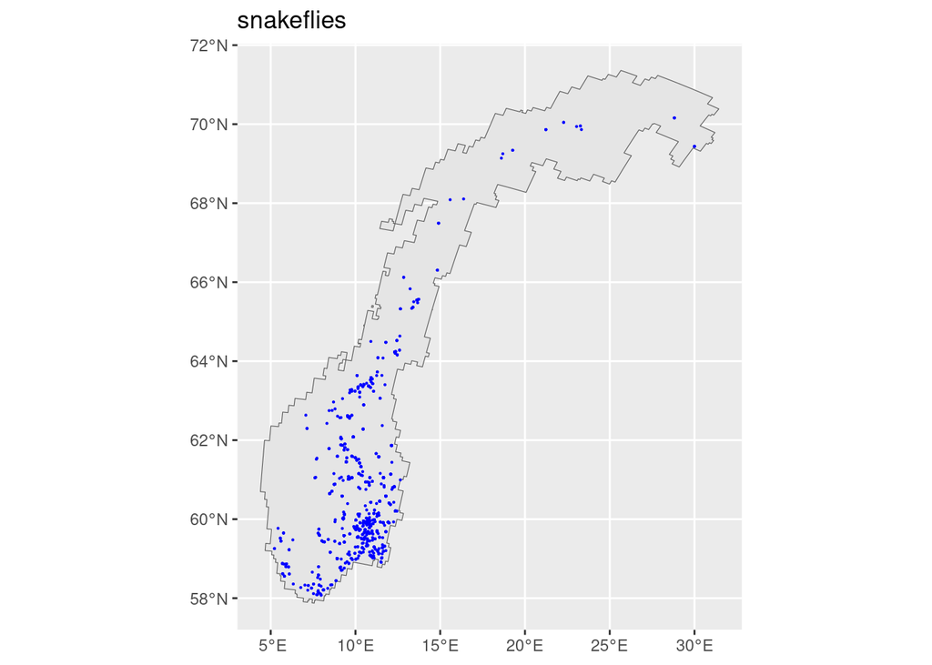

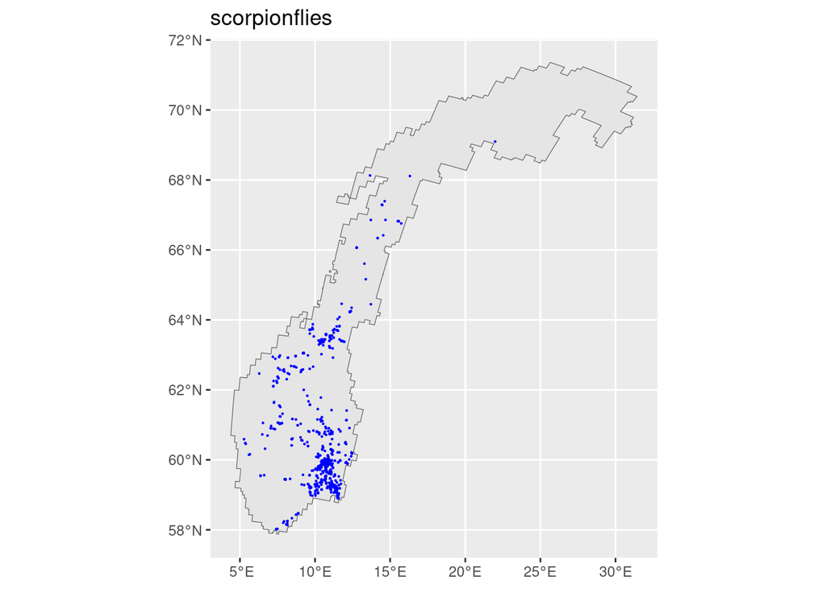

[1 more figures not shown]

## Appendices

### Appendix 1

The tables below give further information on the observations used for our pipeline run.

Total numbers of observations used in pipeline run for each dataset by taxa.

| taxa | dsName | Observations |
| --- | --- | --- |
| aquaticInsects | Freshwater benthic invertebrates ecological collection NTNU University Museum | 8944049 |
| aquaticInsects | Norwegian Species Observation Service | 53595 |
| aquaticInsects | National insect monitoring in Norway | 26027 |
| aquaticInsects | Terrestrial and limnic invertebrates systematic collection, NTNU University Museum | 13418 |
| aquaticInsects | Entomology, Oslo (O) UiO | 4168 |
| aquaticInsects | Artportalen | 4083 |
| aquaticInsects | Entomology collection, UiT Tromsø Museum | 1788 |
| aquaticInsects | Arthropod collection, UiT Tromsø Museum | 877 |
| aquaticInsects | Observation.org, Nature data from around the World | 800 |
| aquaticInsects | iNaturalist Research-grade Observations | 628 |
| aquaticInsects | Natural History Museum Rotterdam - Specimens | 88 |
| aquaticInsects | naturgucker | 84 |
| aquaticInsects | Hatikka.fi observations | 43 |
| aquaticInsects | Entomological collections, UiB | 7 |
| aquaticInsects | Insect collection, UiT, University Museum (TSZ). Insect labeling project and PhD-duty-work | 5 |
| aquaticInsects | Jordal | 4 |
| beetles | Freshwater benthic invertebrates ecological collection NTNU University Museum | 3695011 |
| beetles | Effects of vegetation clearing and dead wood on beetles in power line clearings southeast Norway | 225292 |
| beetles | Norwegian Species Observation Service | 118078 |
| beetles | Beetles in previous clear-cut and near natural mature spruce forests in southern Norway | 109310 |
| beetles | NINA insect database | 102000 |
| beetles | National insect monitoring in Norway | 99145 |
| beetles | Terrestrial and limnic invertebrates systematic collection, NTNU University Museum | 32289 |
| beetles | Saproxylic and herbivorous beetle species in old near-natural and old managed forests in south-eastern Norway | 30601 |
| beetles | Entomology, Oslo (O) UiO | 17933 |
| beetles | Artportalen | 6990 |
| beetles | Coleoptera collection, NHM | 3702 |
| beetles | iNaturalist Research-grade Observations | 2729 |
| beetles | Saproxylic insects caught in window traps and hatched from polypores in small and large old forests in southern Norway | 2180 |
| beetles | Observation.org, Nature data from around the World | 403 |

[output cut: 153 more lines]

Total numbers of observations used in pipeline run for each data type by taxa.

| taxa | dataType | Observations |
| --- | --- | --- |
| aquaticInsects | PA | 8944049 |
| aquaticInsects | PO | 79588 |
| aquaticInsects | Counts | 26027 |
| beetles | PA | 4062394 |
| beetles | PO | 285222 |
| beetles | Counts | 99145 |
| bugs | PA | 1221630 |
| bugs | Counts | 50144 |
| bugs | PO | 47368 |
| butterfliesMoths | PA | 2547420 |
| butterfliesMoths | PO | 1210127 |
| butterfliesMoths | Counts | 199908 |
| cockroaches | PO | 2450 |
| cockroaches | Counts | 310 |
| earwigs | PO | 1521 |
| flies | PA | 4467287 |
| flies | Counts | 502323 |
| flies | PO | 191225 |
| grasshopperLikeInsects | PO | 8380 |
| grasshopperLikeInsects | Counts | 2547 |
| hymenopterans | PA | 1087338 |
| hymenopterans | PO | 204331 |
| hymenopterans | Counts | 144333 |
| netWingedInsects | Counts | 6782 |
| netWingedInsects | PO | 4658 |
| scorpionflies | PO | 1683 |
| snakeflies | Counts | 750 |
| snakeflies | PO | 451 |
| spiders | PO | 69971 |
| spiders | Counts | 25054 |